# Aspect Ratio of Artworks through Time

## Pre-Tate Gallery Artwork Acqusition

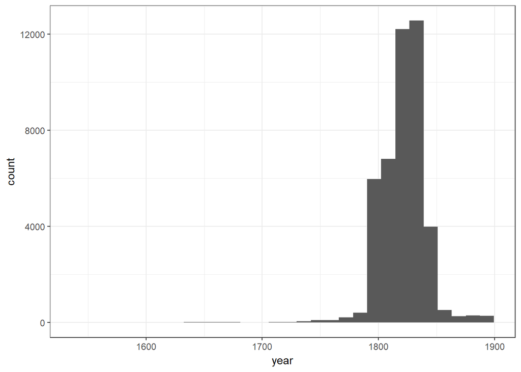

```r
artworks_pre_tate <- artworks_rem[artworks_rem$year <= 1897,]

ggplot(artworks_pre_tate) +
  geom_histogram(aes(year), bins = 30) +
  theme_bw()
```

Let’s see what artists makes up the pre-Tate collection.

```r
sort(table(artworks_pre_tate$artist), decreasing = T)[1:5]
```

```
##
## Turner, Joseph Mallord William               Daniell, William
##                          39046                            612
##                Constable, John                 Blake, William
##                            188                            175
##                  Flaxman, John
##                            151
```

```r
sort(table(artworks_pre_tate$artist), decreasing = T)[1] / sum(table(artworks_pre_tate$artist))
```

```
## Turner, Joseph Mallord William
##                      0.8892077
```

There appears to be a lot of artworks by Turner, making up 89% of the pre-Tate collection. Let’s explore this further.

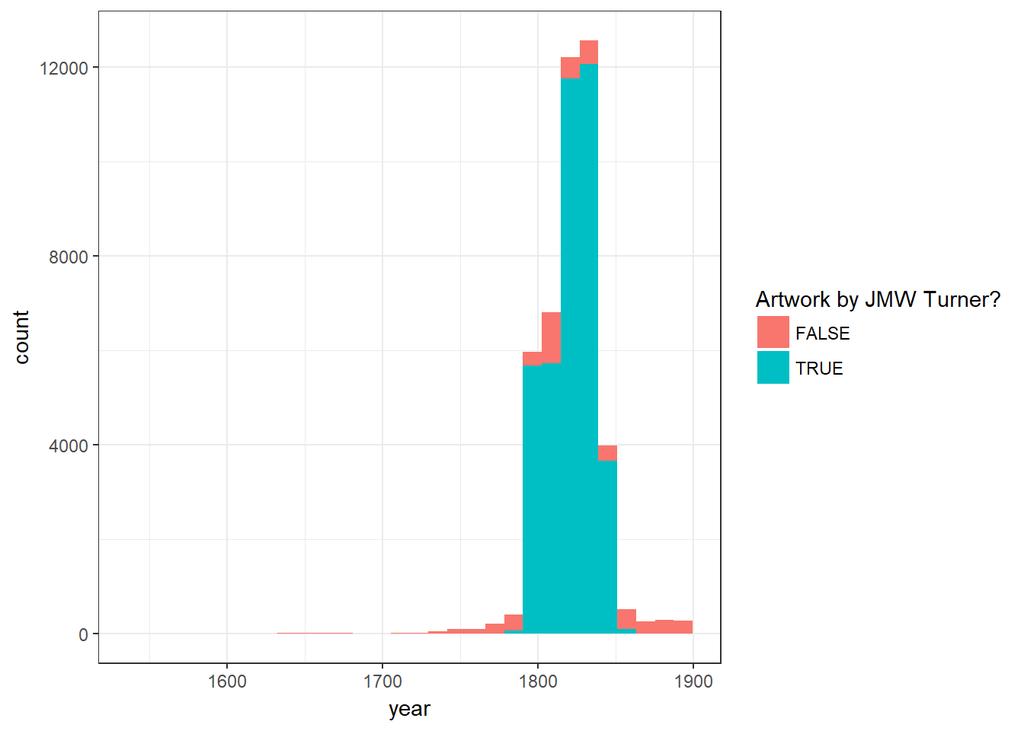

```r
ggplot(artworks_pre_tate) +
  geom_histogram(aes(year, fill = artist == "Turner, Joseph Mallord William"), bins = 30) +
  labs(fill = "Artwork by JMW Turner?") +
  theme_bw()
```

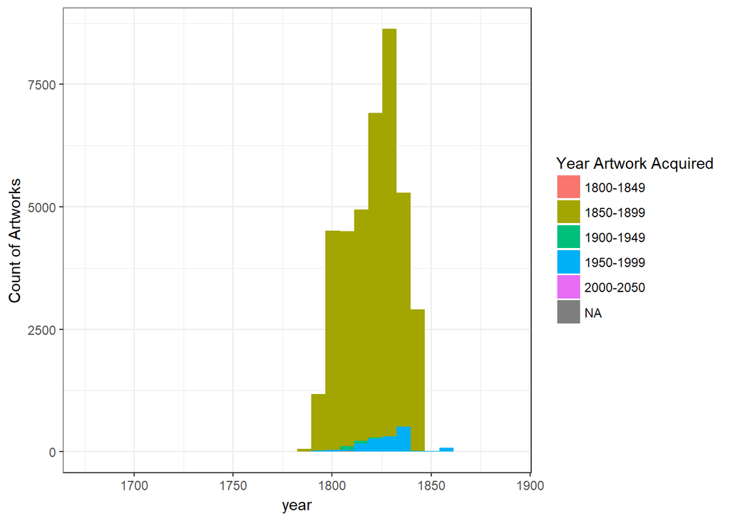

```r
artworks_turner <- artworks_pre_tate[artworks_pre_tate$artist == "Turner, Joseph Mallord William",]

ggplot(artworks_turner) +
  geom_histogram(aes(year, fill = artworks_turner$halfcentury), bins = 30) +
  labs(fill = "Year Artwork Acquired", y = "Count of Artworks") +
  theme_bw()
```

Much like previously found, with the majority of artworks being acquired close to when they were created, the vast majority of artworks by Turner were acquired just after his death in 1851, through the “Turner Bequest”, in which he donated his artworks to the National Gallery, which are now mostly housed in the Clore Gallery at Tate Britain.

# Aspect Ratio through Time

Creation of the aspect ratio (height of artwork / width of artwork)

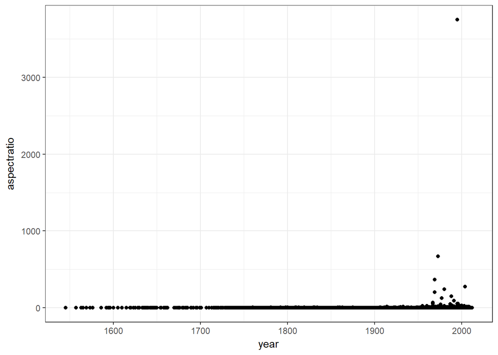

```r
artworks_ar <- artworks_rem[!(is.na(artworks_rem$height & artworks_rem$width &artworks_rem$year)), ]

artworks_ar$aspectratio <- artworks_ar$height / artworks_ar$width

ggplot(artworks_ar) +
  geom_point(aes(year, aspectratio)) +
  theme_bw()
```

As seen from above, the aspect ratio of artworks within the Tate are relatively static. That is, until ~1950s, where the aspect ratios of some artworks changes dramatically.

One artwork, in particular, has an aspect ratio of > 3000. Let’s check to see whether this is an error in the data, or in fact a real artwork.

```r
artworks_ar <- artworks_ar[order(artworks_ar$aspectratio),]

artworks_ar[artworks_ar$aspectratio > 3000,]
```

```
##          id          artist              title medium year acquisitionYear
## 40103 21561 Balka, Miroslaw [diameter]1 x 3750  Steel 1995            1996
##                            dimensions width height depth halfcentury
## 40103 unconfirmed: 10 x 37500 x 10 mm    10  37500    10   1950-1999
##       aspectratio
## 40103        3750
```

From above, it is in fact a real artwork. Created by Balka in 1995, the piece, according to Tate Gallery, conceptulises grief and memory.

[figure not shown]

## The Rise of Postmodernism

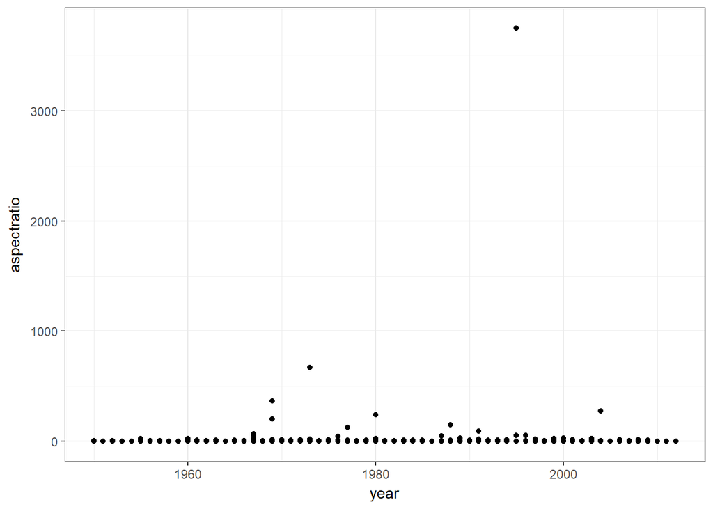

```r
artworks_ar_1950 <- artworks_ar[artworks_ar$year >= 1950,]

ggplot(artworks_ar_1950) +
  geom_point(aes(year, aspectratio)) +
  theme_bw()
```

As seen above, the 1950s onwards saw artworks with greater aspect ratios.

This is seen further by visualising the actual shape of the paintings.

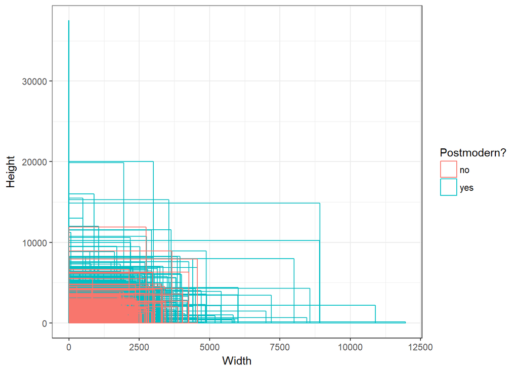

```r
artworks_ar$postmodern <- ifelse(artworks_ar$year >= 1950, 'yes', 'no')

artworks_ar <- artworks_ar[rev(order(artworks_ar$postmodern)),]

ggplot(artworks_ar, aes(xmin = 0, xmax = width, ymin = 0, ymax = height, color = postmodern)) +
  geom_rect(alpha = 0) +
  labs(color="Postmodern?", x = "Width", y = "Height") +
  theme_bw()
```

# Using Aspect Ratio to Predict Year of Artwork Creation

```r
artworks_ar$century <- cut(artworks_ar$year, breaks = c(1500,1550,1600,1650,1700,1750,1800,1850,1900,1950,2000,2050),labels = c("1500-1549", "1550-1600","1600-1649","1650-1699","1700-1749","1750-1799","1800-1849","1850-1899","1900-1949", "1950-1999","2000-2050"), include.lowest = TRUE)

sample <- sample.split(artworks_ar$century, SplitRatio=0.7)

train <- artworks_ar[sample,]
test  <- artworks_ar[!sample,]
```

```r
rf <-  randomForest(train$century ~ aspectratio, ntree = 500, data = train)

print(rf)
```

```
##
## Call:
##  randomForest(formula = train$century ~ aspectratio, data = train,      ntree = 500)
##                Type of random forest: classification
##                      Number of trees: 500
## No. of variables tried at each split: 1
##
##         OOB estimate of  error rate: 23.2%
## Confusion matrix:
##           1500-1549 1550-1600 1600-1649 1650-1699 1700-1749 1750-1799
## 1500-1549         0         0         0         0         0         0
## 1550-1600         0         0         0         0         0         1
## 1600-1649         0         0         0         0         0         1
## 1650-1699         0         0         0         0         0         4
## 1700-1749         0         0         0         0         5        11
## 1750-1799         0         0         1         1         8      1864
## 1800-1849         0         2         2         2        29       267
## 1850-1899         0         0         2         1         8        37
## 1900-1949         0         0         6         6        13       158
## 1950-1999         1         8         9        14        46       421
## 2000-2050         0         0         0         1         2        22
##           1800-1849 1850-1899 1900-1949 1950-1999 2000-2050 class.error
## 1500-1549         0         0         0         1         0   1.0000000
## 1550-1600         2         0         0         7         0   1.0000000
## 1600-1649         4         1         5        16         0   1.0000000
## 1650-1699         6         1         5        17         1   1.0000000
## 1700-1749        28         5        18        49         4   0.9583333
## 1750-1799       523        28       112       350        26   0.3601099
## 1800-1849     24128       148       302      1105        79   0.0742787
## 1850-1899       273        97       142       372        25   0.8986416
## 1900-1949       497       116       609      1037        56   0.7562050
## 1950-1999      1754       285       874      6106       199   0.3716168
## 2000-2050       119        16        48       272       338   0.5867971
```

```r
train$predicted_response <- predict(rf, train)

print(confusionMatrix(data = train$predicted_response,reference = train$century))
```

```
## Confusion Matrix and Statistics
##
##            Reference
## Prediction  1500-1549 1550-1600 1600-1649 1650-1699 1700-1749 1750-1799
##   1500-1549         1         0         0         0         0         0
##   1550-1600         0         8         0         0         0         0
##   1600-1649         0         0        21         0         0         0
##   1650-1699         0         0         0        23         0         0
##   1700-1749         0         0         0         0        92         1
##   1750-1799         0         0         0         1         2      2535
##   1800-1849         0         1         0         3        13       290
##   1850-1899         0         0         0         0         2         1
##   1900-1949         0         0         0         1         4        11
##   1950-1999         0         1         6         6         6        66
##   2000-2050         0         0         0         0         1         9
##            Reference
## Prediction  1800-1849 1850-1899 1900-1949 1950-1999 2000-2050
##   1500-1549         0         0         0         0         0
##   1550-1600         0         0         0         0         0
##   1600-1649         0         0         1         0         0
##   1650-1699         0         0         0         0         0
##   1700-1749         1         2         4         6         0
##   1750-1799        83        16        62       113         8
##   1800-1849     25657       110       236       677        59
##   1850-1899         8       660        25        23         1
##   1900-1949        50        45      1806       130         5
##   1950-1999       246       118       343      8734       132
##   2000-2050        19         6        21        34       613
##
## Overall Statistics
##
##                Accuracy : 0.9303
##                  95% CI : (0.9278, 0.9327)
##     No Information Rate : 0.6039
##     P-Value [Acc > NIR] : < 2.2e-16
##
##                   Kappa : 0.8762
##  Mcnemar's Test P-Value : NA
##
## Statistics by Class:
```

[output cut: 22 more lines]

```
## Pos Pred Value                 0.9486          0.91667          0.88012
## Neg Pred Value                 0.9747          0.99300          0.98317
## Prevalence                     0.6039          0.02217          0.05788
## Detection Rate                 0.5945          0.01529          0.04185
## Detection Prevalence           0.6267          0.01668          0.04755
## Balanced Accuracy              0.9516          0.84412          0.85846
##                      Class: 1950-1999 Class: 2000-2050
## Sensitivity                    0.8988          0.74939
## Specificity                    0.9724          0.99787
## Pos Pred Value                 0.9043          0.87198
## Neg Pred Value                 0.9707          0.99517
## Prevalence                     0.2251          0.01895
## Detection Rate                 0.2024          0.01420
## Detection Prevalence           0.2238          0.01629
## Balanced Accuracy              0.9356          0.87363
```

```r
test$predicted_response <- predict(rf, test)

print(confusionMatrix(data=test$predicted_response, reference=test$century))
```

```
## Confusion Matrix and Statistics
##
##            Reference
## Prediction  1500-1549 1550-1600 1600-1649 1650-1699 1700-1749 1750-1799
##   1500-1549         0         0         0         0         0         0
##   1550-1600         0         0         0         0         0         0
##   1600-1649         0         0         0         0         0         2
##   1650-1699         0         0         0         0         0         1
##   1700-1749         0         0         0         1         1         3
##   1750-1799         0         0         3         0         5       791
##   1800-1849         0         0         2         2        16       220
##   1850-1899         0         0         0         1         3        17
##   1900-1949         0         0         0         3         4        48
##   1950-1999         1         4         7         8        21       156
##   2000-2050         0         0         0         0         1        11
##            Reference
## Prediction  1800-1849 1850-1899 1900-1949 1950-1999 2000-2050
##   1500-1549         0         0         0         0         0
##   1550-1600         1         1         0         1         0
##   1600-1649         1         1         0         7         0
##   1650-1699         3         0         0         6         0
##   1700-1749         8         2         7        21         0
##   1750-1799       106        14        58       168         8
##   1800-1849     10322       110       253       703        48
##   1850-1899        75        44        57       121         3
##   1900-1949       126        58       253       357        25
##   1950-1999       494       169       422      2702       126
##   2000-2050        35        11        20        78       141
##
## Overall Statistics
##
##                Accuracy : 0.7706
##                  95% CI : (0.7644, 0.7766)
##     No Information Rate : 0.6039
##     P-Value [Acc > NIR] : < 2.2e-16
##
##                   Kappa : 0.5912
##  Mcnemar's Test P-Value : NA
##
## Statistics by Class:
```

[output cut: 22 more lines]

```
## Pos Pred Value                 0.8840         0.137072          0.28947
## Neg Pred Value                 0.8755         0.979865          0.95364
## Prevalence                     0.6039         0.022165          0.05784
## Detection Rate                 0.5580         0.002379          0.01368
## Detection Prevalence           0.6312         0.017353          0.04725
## Balanced Accuracy              0.8696         0.546002          0.60041
##                      Class: 1950-1999 Class: 2000-2050
## Sensitivity                    0.6489         0.401709
## Specificity                    0.9018         0.991404
## Pos Pred Value                 0.6574         0.474747
## Neg Pred Value                 0.8984         0.988462
## Prevalence                     0.2251         0.018975
## Detection Rate                 0.1461         0.007622
## Detection Prevalence           0.2222         0.016056
## Balanced Accuracy              0.7753         0.696556
```